# Risk Factor Analysis

## Outcome Variable

**Outcome Variable:** stunted

## Predictor Variables

**Intervention Variable:** birthlen

**Adjustment Set:**

- arm
- sex
- W_mage
- meducyrs
- feducyrs
- hhwealth_quart
- vagbrth
- W_nrooms
- brthmon
- W_parity
- impfloor
- impsan
- safeh20
- delta_W_mage
- delta_meducyrs
- delta_feducyrs
- delta_hhwealth_quart
- delta_vagbrth
- delta_W_nrooms
- delta_brthmon
- delta_W_parity
- delta_impfloor
- delta_impsan
- delta_safeh20

## Stratifying Variables

The analysis was stratified on these variable(s):

- agecat
- studyid
- country

## Data Summary

| agecat | studyid | country | birthlen | stunted | n_cell | n |
| --- | --- | --- | --- | --- | --- | --- |
| Birth | ki0047075b-MAL-ED | BANGLADESH | >=50 cm | 0 | 29 | 257 |
| Birth | ki0047075b-MAL-ED | BANGLADESH | >=50 cm | 1 | 0 | 257 |
| Birth | ki0047075b-MAL-ED | BANGLADESH | <48 cm | 0 | 97 | 257 |
| Birth | ki0047075b-MAL-ED | BANGLADESH | <48 cm | 1 | 47 | 257 |
| Birth | ki0047075b-MAL-ED | BANGLADESH | [48-50) cm | 0 | 84 | 257 |
| Birth | ki0047075b-MAL-ED | BANGLADESH | [48-50) cm | 1 | 0 | 257 |
| Birth | ki0047075b-MAL-ED | BRAZIL | >=50 cm | 0 | 34 | 191 |
| Birth | ki0047075b-MAL-ED | BRAZIL | >=50 cm | 1 | 0 | 191 |
| Birth | ki0047075b-MAL-ED | BRAZIL | <48 cm | 0 | 59 | 191 |
| Birth | ki0047075b-MAL-ED | BRAZIL | <48 cm | 1 | 21 | 191 |
| Birth | ki0047075b-MAL-ED | BRAZIL | [48-50) cm | 0 | 77 | 191 |
| Birth | ki0047075b-MAL-ED | BRAZIL | [48-50) cm | 1 | 0 | 191 |
| Birth | ki0047075b-MAL-ED | INDIA | >=50 cm | 0 | 25 | 206 |
| Birth | ki0047075b-MAL-ED | INDIA | >=50 cm | 1 | 0 | 206 |
| Birth | ki0047075b-MAL-ED | INDIA | <48 cm | 0 | 74 | 206 |
| Birth | ki0047075b-MAL-ED | INDIA | <48 cm | 1 | 33 | 206 |
| Birth | ki0047075b-MAL-ED | INDIA | [48-50) cm | 0 | 74 | 206 |
| Birth | ki0047075b-MAL-ED | INDIA | [48-50) cm | 1 | 0 | 206 |
| Birth | ki0047075b-MAL-ED | NEPAL | >=50 cm | 0 | 38 | 173 |
| Birth | ki0047075b-MAL-ED | NEPAL | >=50 cm | 1 | 0 | 173 |
| Birth | ki0047075b-MAL-ED | NEPAL | <48 cm | 0 | 51 | 173 |
| Birth | ki0047075b-MAL-ED | NEPAL | <48 cm | 1 | 18 | 173 |
| Birth | ki0047075b-MAL-ED | NEPAL | [48-50) cm | 0 | 66 | 173 |
| Birth | ki0047075b-MAL-ED | NEPAL | [48-50) cm | 1 | 0 | 173 |
| Birth | ki0047075b-MAL-ED | PERU | >=50 cm | 0 | 34 | 287 |
| Birth | ki0047075b-MAL-ED | PERU | >=50 cm | 1 | 0 | 287 |
| Birth | ki0047075b-MAL-ED | PERU | <48 cm | 0 | 108 | 287 |
| Birth | ki0047075b-MAL-ED | PERU | <48 cm | 1 | 34 | 287 |
| Birth | ki0047075b-MAL-ED | PERU | [48-50) cm | 0 | 111 | 287 |
| Birth | ki0047075b-MAL-ED | PERU | [48-50) cm | 1 | 0 | 287 |

[output cut: 432 more lines]

The following strata were considered:

- agecat: 24 months, studyid: ki0047075b-MAL-ED, country: BANGLADESH
- agecat: 24 months, studyid: ki0047075b-MAL-ED, country: BRAZIL
- agecat: 24 months, studyid: ki0047075b-MAL-ED, country: INDIA
- agecat: 24 months, studyid: ki0047075b-MAL-ED, country: NEPAL
- agecat: 24 months, studyid: ki0047075b-MAL-ED, country: PERU
- agecat: 24 months, studyid: ki0047075b-MAL-ED, country: SOUTH AFRICA
- agecat: 24 months, studyid: ki0047075b-MAL-ED, country: TANZANIA, UNITED REPUBLIC OF
- agecat: 24 months, studyid: ki1000108-CMC-V-BCS-2002, country: INDIA
- agecat: 24 months, studyid: ki1000108-IRC, country: INDIA
- agecat: 24 months, studyid: ki1017093-NIH-Birth, country: BANGLADESH
- agecat: 24 months, studyid: ki1017093b-PROVIDE, country: BANGLADESH
- agecat: 24 months, studyid: ki1017093c-NIH-Crypto, country: BANGLADESH
- agecat: 24 months, studyid: ki1101329-Keneba, country: GAMBIA
- agecat: 24 months, studyid: ki1114097-CMIN, country: BANGLADESH
- agecat: 24 months, studyid: ki1114097-CMIN, country: PERU
- agecat: 24 months, studyid: ki1114097-CONTENT, country: PERU
- agecat: 24 months, studyid: ki1119695-PROBIT, country: BELARUS
- agecat: 24 months, studyid: ki1126311-ZVITAMBO, country: ZIMBABWE
- agecat: 24 months, studyid: ki1135781-COHORTS, country: GUATEMALA
- agecat: 24 months, studyid: ki1135781-COHORTS, country: INDIA
- agecat: 24 months, studyid: ki1135781-COHORTS, country: PHILIPPINES
- agecat: 24 months, studyid: kiGH5241-JiVitA-3, country: BANGLADESH
- agecat: 24 months, studyid: kiGH5241-JiVitA-4, country: BANGLADESH
- agecat: 6 months, studyid: ki0047075b-MAL-ED, country: BANGLADESH
- agecat: 6 months, studyid: ki0047075b-MAL-ED, country: BRAZIL
- agecat: 6 months, studyid: ki0047075b-MAL-ED, country: INDIA
- agecat: 6 months, studyid: ki0047075b-MAL-ED, country: NEPAL
- agecat: 6 months, studyid: ki0047075b-MAL-ED, country: PERU
- agecat: 6 months, studyid: ki0047075b-MAL-ED, country: SOUTH AFRICA
- agecat: 6 months, studyid: ki0047075b-MAL-ED, country: TANZANIA, UNITED REPUBLIC OF
- agecat: 6 months, studyid: ki1000108-CMC-V-BCS-2002, country: INDIA
- agecat: 6 months, studyid: ki1000108-IRC, country: INDIA
- agecat: 6 months, studyid: ki1000109-EE, country: PAKISTAN
- agecat: 6 months, studyid: ki1000109-ResPak, country: PAKISTAN
- agecat: 6 months, studyid: ki1000304b-SAS-CompFeed, country: INDIA
- agecat: 6 months, studyid: ki1017093-NIH-Birth, country: BANGLADESH
- agecat: 6 months, studyid: ki1017093b-PROVIDE, country: BANGLADESH
- agecat: 6 months, studyid: ki1017093c-NIH-Crypto, country: BANGLADESH
- agecat: 6 months, studyid: ki1101329-Keneba, country: GAMBIA
- agecat: 6 months, studyid: ki1114097-CMIN, country: BANGLADESH
- agecat: 6 months, studyid: ki1114097-CMIN, country: BRAZIL
- agecat: 6 months, studyid: ki1114097-CMIN, country: GUINEA-BISSAU
- agecat: 6 months, studyid: ki1114097-CMIN, country: PERU
- agecat: 6 months, studyid: ki1114097-CONTENT, country: PERU
- agecat: 6 months, studyid: ki1119695-PROBIT, country: BELARUS
- agecat: 6 months, studyid: ki1126311-ZVITAMBO, country: ZIMBABWE
- agecat: 6 months, studyid: ki1135781-COHORTS, country: GUATEMALA
- agecat: 6 months, studyid: ki1135781-COHORTS, country: INDIA
- agecat: 6 months, studyid: ki1135781-COHORTS, country: PHILIPPINES
- agecat: 6 months, studyid: kiGH5241-JiVitA-3, country: BANGLADESH
- agecat: 6 months, studyid: kiGH5241-JiVitA-4, country: BANGLADESH
- agecat: Birth, studyid: ki0047075b-MAL-ED, country: BANGLADESH
- agecat: Birth, studyid: ki0047075b-MAL-ED, country: BRAZIL
- agecat: Birth, studyid: ki0047075b-MAL-ED, country: INDIA
- agecat: Birth, studyid: ki0047075b-MAL-ED, country: NEPAL
- agecat: Birth, studyid: ki0047075b-MAL-ED, country: PERU
- agecat: Birth, studyid: ki0047075b-MAL-ED, country: SOUTH AFRICA
- agecat: Birth, studyid: ki0047075b-MAL-ED, country: TANZANIA, UNITED REPUBLIC OF
- agecat: Birth, studyid: ki1000108-CMC-V-BCS-2002, country: INDIA
- agecat: Birth, studyid: ki1000108-IRC, country: INDIA
- agecat: Birth, studyid: ki1000109-EE, country: PAKISTAN
- agecat: Birth, studyid: ki1000109-ResPak, country: PAKISTAN
- agecat: Birth, studyid: ki1000304b-SAS-CompFeed, country: INDIA
- agecat: Birth, studyid: ki1017093-NIH-Birth, country: BANGLADESH
- agecat: Birth, studyid: ki1017093c-NIH-Crypto, country: BANGLADESH
- agecat: Birth, studyid: ki1101329-Keneba, country: GAMBIA
- agecat: Birth, studyid: ki1114097-CMIN, country: BANGLADESH
- agecat: Birth, studyid: ki1114097-CMIN, country: BRAZIL
- agecat: Birth, studyid: ki1114097-CMIN, country: PERU
- agecat: Birth, studyid: ki1114097-CONTENT, country: PERU
- agecat: Birth, studyid: ki1119695-PROBIT, country: BELARUS
- agecat: Birth, studyid: ki1126311-ZVITAMBO, country: ZIMBABWE
- agecat: Birth, studyid: ki1135781-COHORTS, country: GUATEMALA
- agecat: Birth, studyid: ki1135781-COHORTS, country: INDIA
- agecat: Birth, studyid: ki1135781-COHORTS, country: PHILIPPINES
- agecat: Birth, studyid: kiGH5241-JiVitA-3, country: BANGLADESH
- agecat: Birth, studyid: kiGH5241-JiVitA-4, country: BANGLADESH

### Dropped Strata

Some strata were dropped due to rare outcomes:

- agecat: Birth, studyid: ki0047075b-MAL-ED, country: BANGLADESH
- agecat: Birth, studyid: ki0047075b-MAL-ED, country: BRAZIL
- agecat: Birth, studyid: ki0047075b-MAL-ED, country: INDIA
- agecat: Birth, studyid: ki0047075b-MAL-ED, country: NEPAL
- agecat: Birth, studyid: ki0047075b-MAL-ED, country: PERU
- agecat: Birth, studyid: ki0047075b-MAL-ED, country: SOUTH AFRICA
- agecat: Birth, studyid: ki0047075b-MAL-ED, country: TANZANIA, UNITED REPUBLIC OF
- agecat: Birth, studyid: ki1000108-CMC-V-BCS-2002, country: INDIA
- agecat: Birth, studyid: ki1000108-IRC, country: INDIA
- agecat: Birth, studyid: ki1000109-EE, country: PAKISTAN
- agecat: Birth, studyid: ki1000109-ResPak, country: PAKISTAN
- agecat: Birth, studyid: ki1000304b-SAS-CompFeed, country: INDIA
- agecat: Birth, studyid: ki1017093-NIH-Birth, country: BANGLADESH
- agecat: Birth, studyid: ki1017093c-NIH-Crypto, country: BANGLADESH
- agecat: Birth, studyid: ki1101329-Keneba, country: GAMBIA
- agecat: Birth, studyid: ki1114097-CMIN, country: BANGLADESH
- agecat: Birth, studyid: ki1114097-CMIN, country: BRAZIL
- agecat: Birth, studyid: ki1114097-CMIN, country: PERU
- agecat: Birth, studyid: ki1114097-CONTENT, country: PERU
- agecat: Birth, studyid: ki1119695-PROBIT, country: BELARUS
- agecat: Birth, studyid: ki1126311-ZVITAMBO, country: ZIMBABWE
- agecat: Birth, studyid: ki1135781-COHORTS, country: GUATEMALA
- agecat: Birth, studyid: ki1135781-COHORTS, country: INDIA
- agecat: Birth, studyid: ki1135781-COHORTS, country: PHILIPPINES
- agecat: Birth, studyid: kiGH5241-JiVitA-3, country: BANGLADESH
- agecat: Birth, studyid: kiGH5241-JiVitA-4, country: BANGLADESH
- agecat: 6 months, studyid: ki0047075b-MAL-ED, country: BANGLADESH
- agecat: 6 months, studyid: ki0047075b-MAL-ED, country: BRAZIL
- agecat: 6 months, studyid: ki0047075b-MAL-ED, country: INDIA
- agecat: 6 months, studyid: ki0047075b-MAL-ED, country: NEPAL
- agecat: 6 months, studyid: ki0047075b-MAL-ED, country: PERU
- agecat: 6 months, studyid: ki0047075b-MAL-ED, country: SOUTH AFRICA
- agecat: 6 months, studyid: ki0047075b-MAL-ED, country: TANZANIA, UNITED REPUBLIC OF
- agecat: 6 months, studyid: ki1000109-EE, country: PAKISTAN
- agecat: 6 months, studyid: ki1000109-ResPak, country: PAKISTAN
- agecat: 6 months, studyid: ki1017093-NIH-Birth, country: BANGLADESH
- agecat: 6 months, studyid: ki1017093b-PROVIDE, country: BANGLADESH
- agecat: 6 months, studyid: ki1017093c-NIH-Crypto, country: BANGLADESH
- agecat: 6 months, studyid: ki1114097-CMIN, country: BANGLADESH
- agecat: 6 months, studyid: ki1114097-CMIN, country: BRAZIL
- agecat: 6 months, studyid: ki1114097-CMIN, country: GUINEA-BISSAU
- agecat: 6 months, studyid: ki1114097-CMIN, country: PERU
- agecat: 6 months, studyid: ki1114097-CONTENT, country: PERU
- agecat: 24 months, studyid: ki0047075b-MAL-ED, country: BANGLADESH
- agecat: 24 months, studyid: ki0047075b-MAL-ED, country: BRAZIL
- agecat: 24 months, studyid: ki0047075b-MAL-ED, country: INDIA
- agecat: 24 months, studyid: ki0047075b-MAL-ED, country: NEPAL
- agecat: 24 months, studyid: ki0047075b-MAL-ED, country: TANZANIA, UNITED REPUBLIC OF
- agecat: 24 months, studyid: ki1017093-NIH-Birth, country: BANGLADESH
- agecat: 24 months, studyid: ki1114097-CMIN, country: BANGLADESH
- agecat: 24 months, studyid: ki1114097-CMIN, country: PERU
- agecat: 24 months, studyid: ki1114097-CONTENT, country: PERU

## Methods Detail

We’re interested in the causal parameters $E[Y_a]$ for all values of $a \in \mathcal{A}$. These parameters represent the mean outcome if, possibly contrary to fact, we intervened to set all units to have $A=a$. Under the randomization and positivity assumptions, these are identified by the statistical parameters $\psi_a=E_W[E_{Y|A,W}(Y|A=a,W)]$. In addition, we’re interested in the mean of $Y$, $E[Y]$ under no intervention (the observed mean). We will estimate these parameters by using SuperLearner to fit the relevant likelihood factors – $E_{Y|A,W}(Y|A=a,W)$ and $p(A=a|W)$, and then updating our likelihood fit using a joint TMLE.

For unadjusted analyses ($W=\{\}$), initial likelihoods were estimated using Lrnr_glm to estimate the simple $E(Y|A)$ and Lrnr_mean to estimate $p(A)$. For adjusted analyses, a small library containing Lrnr_glmnet, Lrnr_xgboost, and Lrnr_mean was used.

Having estimated these parameters, we will then use the delta method to estimate relative risks and attributable risks relative to a prespecified baseline level of $A$.

# Results Detail

## Results Plots

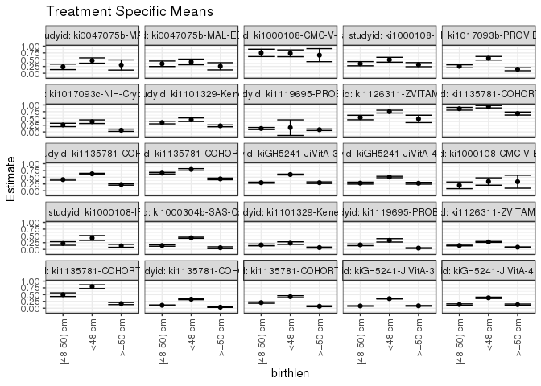

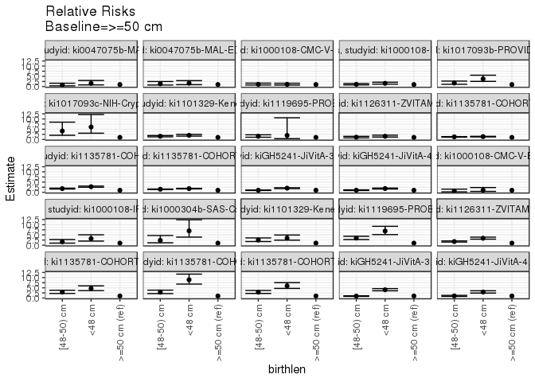

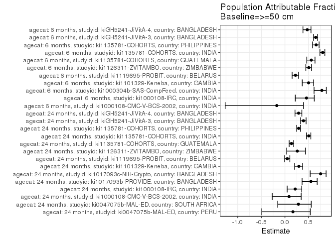

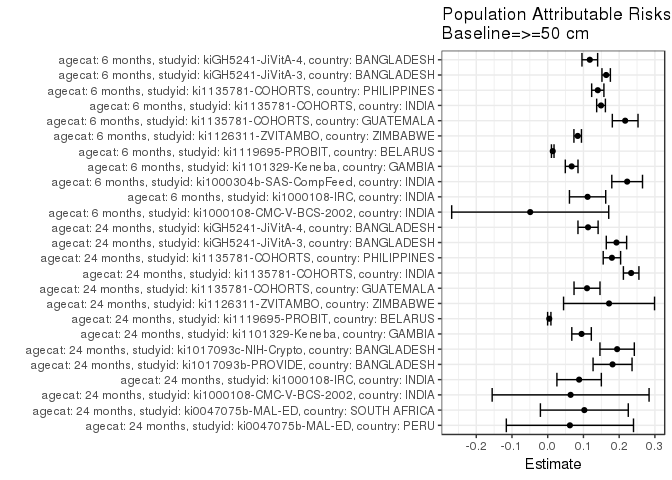

## Results Table

### Parameter: TSM

| agecat | studyid | country | intervention_level | baseline_level | estimate | ci_lower | ci_upper |
| --- | --- | --- | --- | --- | --- | --- | --- |
| 6 months | ki1000108-CMC-V-BCS-2002 | INDIA | >=50 cm | NA | 0.3333333 | 0.0935960 | 0.5730706 |
| 6 months | ki1000108-CMC-V-BCS-2002 | INDIA | <48 cm | NA | 0.3404255 | 0.2042869 | 0.4765642 |
| 6 months | ki1000108-CMC-V-BCS-2002 | INDIA | [48-50) cm | NA | 0.2000000 | 0.0754288 | 0.3245712 |
| 6 months | ki1000108-IRC | INDIA | >=50 cm | NA | 0.1326290 | 0.0779579 | 0.1873000 |
| 6 months | ki1000108-IRC | INDIA | <48 cm | NA | 0.4221703 | 0.3324969 | 0.5118438 |
| 6 months | ki1000108-IRC | INDIA | [48-50) cm | NA | 0.2188791 | 0.1526819 | 0.2850762 |
| 6 months | ki1000304b-SAS-CompFeed | INDIA | >=50 cm | NA | 0.0616201 | 0.0280603 | 0.0951798 |
| 6 months | ki1000304b-SAS-CompFeed | INDIA | <48 cm | NA | 0.4309114 | 0.4109231 | 0.4508997 |
| 6 months | ki1000304b-SAS-CompFeed | INDIA | [48-50) cm | NA | 0.1447931 | 0.1178532 | 0.1717331 |
| 6 months | ki1101329-Keneba | GAMBIA | >=50 cm | NA | 0.0666179 | 0.0477340 | 0.0855018 |
| 6 months | ki1101329-Keneba | GAMBIA | <48 cm | NA | 0.2326304 | 0.1844819 | 0.2807789 |
| 6 months | ki1101329-Keneba | GAMBIA | [48-50) cm | NA | 0.1669163 | 0.1338179 | 0.2000147 |
| 6 months | ki1119695-PROBIT | BELARUS | >=50 cm | NA | 0.0486359 | 0.0350074 | 0.0622643 |
| 6 months | ki1119695-PROBIT | BELARUS | <48 cm | NA | 0.3357426 | 0.2728929 | 0.3985924 |
| 6 months | ki1119695-PROBIT | BELARUS | [48-50) cm | NA | 0.1681252 | 0.1364238 | 0.1998266 |
| 6 months | ki1126311-ZVITAMBO | ZIMBABWE | >=50 cm | NA | 0.0818097 | 0.0709739 | 0.0926454 |
| 6 months | ki1126311-ZVITAMBO | ZIMBABWE | <48 cm | NA | 0.2778351 | 0.2610040 | 0.2946663 |
| 6 months | ki1126311-ZVITAMBO | ZIMBABWE | [48-50) cm | NA | 0.1442967 | 0.1323221 | 0.1562713 |
| 6 months | ki1135781-COHORTS | GUATEMALA | >=50 cm | NA | 0.1712721 | 0.1315811 | 0.2109630 |
| 6 months | ki1135781-COHORTS | GUATEMALA | <48 cm | NA | 0.7951698 | 0.7262604 | 0.8640793 |
| 6 months | ki1135781-COHORTS | GUATEMALA | [48-50) cm | NA | 0.5000145 | 0.4322335 | 0.5677956 |
| 6 months | ki1135781-COHORTS | INDIA | >=50 cm | NA | 0.0372303 | 0.0273548 | 0.0471058 |
| 6 months | ki1135781-COHORTS | INDIA | <48 cm | NA | 0.3322510 | 0.3142223 | 0.3502797 |
| 6 months | ki1135781-COHORTS | INDIA | [48-50) cm | NA | 0.1075334 | 0.0949780 | 0.1200888 |
| 6 months | ki1135781-COHORTS | PHILIPPINES | >=50 cm | NA | 0.0716097 | 0.0557197 | 0.0874997 |
| 6 months | ki1135781-COHORTS | PHILIPPINES | <48 cm | NA | 0.4261137 | 0.3914407 | 0.4607868 |
| 6 months | ki1135781-COHORTS | PHILIPPINES | [48-50) cm | NA | 0.2062872 | 0.1822974 | 0.2302770 |
| 6 months | kiGH5241-JiVitA-3 | BANGLADESH | >=50 cm | NA | 0.0870720 | 0.0757002 | 0.0984437 |
| 6 months | kiGH5241-JiVitA-3 | BANGLADESH | <48 cm | NA | 0.3516546 | 0.3412631 | 0.3620461 |
| 6 months | kiGH5241-JiVitA-3 | BANGLADESH | [48-50) cm | NA | 0.0823330 | 0.0735910 | 0.0910749 |
| 6 months | kiGH5241-JiVitA-4 | BANGLADESH | >=50 cm | NA | 0.1309439 | 0.1076866 | 0.1542011 |
| 6 months | kiGH5241-JiVitA-4 | BANGLADESH | <48 cm | NA | 0.3837490 | 0.3579967 | 0.4095014 |
| 6 months | kiGH5241-JiVitA-4 | BANGLADESH | [48-50) cm | NA | 0.1351222 | 0.1100234 | 0.1602210 |
| 24 months | ki0047075b-MAL-ED | PERU | >=50 cm | NA | 0.3043478 | 0.1158071 | 0.4928886 |
| 24 months | ki0047075b-MAL-ED | PERU | <48 cm | NA | 0.4700000 | 0.3719213 | 0.5680787 |
| 24 months | ki0047075b-MAL-ED | PERU | [48-50) cm | NA | 0.2352941 | 0.1342092 | 0.3363790 |
| 24 months | ki0047075b-MAL-ED | SOUTH AFRICA | >=50 cm | NA | 0.2556960 | 0.1223121 | 0.3890799 |
| 24 months | ki0047075b-MAL-ED | SOUTH AFRICA | <48 cm | NA | 0.4174586 | 0.3128783 | 0.5220390 |
| 24 months | ki0047075b-MAL-ED | SOUTH AFRICA | [48-50) cm | NA | 0.3497125 | 0.2480330 | 0.4513921 |
| 24 months | ki1000108-CMC-V-BCS-2002 | INDIA | >=50 cm | NA | 0.6666667 | 0.4269522 | 0.9063811 |
| 24 months | ki1000108-CMC-V-BCS-2002 | INDIA | <48 cm | NA | 0.7346939 | 0.6104786 | 0.8589091 |
| 24 months | ki1000108-CMC-V-BCS-2002 | INDIA | [48-50) cm | NA | 0.7500000 | 0.6151606 | 0.8848394 |
| 24 months | ki1000108-IRC | INDIA | >=50 cm | NA | 0.3172014 | 0.2412298 | 0.3931729 |
| 24 months | ki1000108-IRC | INDIA | <48 cm | NA | 0.4983482 | 0.4085410 | 0.5881554 |
| 24 months | ki1000108-IRC | INDIA | [48-50) cm | NA | 0.3517850 | 0.2737272 | 0.4298429 |
| 24 months | ki1017093b-PROVIDE | BANGLADESH | >=50 cm | NA | 0.1477873 | 0.0923895 | 0.2031850 |
| 24 months | ki1017093b-PROVIDE | BANGLADESH | <48 cm | NA | 0.5533874 | 0.4872005 | 0.6195744 |
| 24 months | ki1017093b-PROVIDE | BANGLADESH | [48-50) cm | NA | 0.2559987 | 0.2013961 | 0.3106014 |
| 24 months | ki1017093c-NIH-Crypto | BANGLADESH | >=50 cm | NA | 0.0625000 | 0.0205249 | 0.1044751 |
| 24 months | ki1017093c-NIH-Crypto | BANGLADESH | <48 cm | NA | 0.3800000 | 0.3126646 | 0.4473354 |
| 24 months | ki1017093c-NIH-Crypto | BANGLADESH | [48-50) cm | NA | 0.2580645 | 0.1951194 | 0.3210096 |
| 24 months | ki1101329-Keneba | GAMBIA | >=50 cm | NA | 0.2254584 | 0.1899221 | 0.2609948 |
| 24 months | ki1101329-Keneba | GAMBIA | <48 cm | NA | 0.4531111 | 0.3870291 | 0.5191931 |
| 24 months | ki1101329-Keneba | GAMBIA | [48-50) cm | NA | 0.3490552 | 0.3001975 | 0.3979130 |
| 24 months | ki1119695-PROBIT | BELARUS | >=50 cm | NA | 0.0809123 | 0.0513729 | 0.1104517 |
| 24 months | ki1119695-PROBIT | BELARUS | <48 cm | NA | 0.1590909 | -0.1304727 | 0.4486545 |
| 24 months | ki1119695-PROBIT | BELARUS | [48-50) cm | NA | 0.1266234 | 0.0879311 | 0.1653157 |
| 24 months | ki1126311-ZVITAMBO | ZIMBABWE | >=50 cm | NA | 0.4830965 | 0.3467682 | 0.6194248 |
| 24 months | ki1126311-ZVITAMBO | ZIMBABWE | <48 cm | NA | 0.7528916 | 0.7004626 | 0.8053207 |
| 24 months | ki1126311-ZVITAMBO | ZIMBABWE | [48-50) cm | NA | 0.5342523 | 0.4510968 | 0.6174078 |
| 24 months | ki1135781-COHORTS | GUATEMALA | >=50 cm | NA | 0.6818182 | 0.6255834 | 0.7380529 |
| 24 months | ki1135781-COHORTS | GUATEMALA | <48 cm | NA | 0.9338843 | 0.8895703 | 0.9781983 |
| 24 months | ki1135781-COHORTS | GUATEMALA | [48-50) cm | NA | 0.8587571 | 0.8074040 | 0.9101102 |
| 24 months | ki1135781-COHORTS | INDIA | >=50 cm | NA | 0.2291556 | 0.2059147 | 0.2523965 |
| 24 months | ki1135781-COHORTS | INDIA | <48 cm | NA | 0.6254509 | 0.6050407 | 0.6458612 |
| 24 months | ki1135781-COHORTS | INDIA | [48-50) cm | NA | 0.4121264 | 0.3904279 | 0.4338248 |
| 24 months | ki1135781-COHORTS | PHILIPPINES | >=50 cm | NA | 0.4374152 | 0.4062956 | 0.4685348 |
| 24 months | ki1135781-COHORTS | PHILIPPINES | <48 cm | NA | 0.7879619 | 0.7577405 | 0.8181833 |
| 24 months | ki1135781-COHORTS | PHILIPPINES | [48-50) cm | NA | 0.6502963 | 0.6209901 | 0.6796026 |
| 24 months | kiGH5241-JiVitA-3 | BANGLADESH | >=50 cm | NA | 0.2971440 | 0.2669299 | 0.3273580 |
| 24 months | kiGH5241-JiVitA-3 | BANGLADESH | <48 cm | NA | 0.5996196 | 0.5844905 | 0.6147487 |
| 24 months | kiGH5241-JiVitA-3 | BANGLADESH | [48-50) cm | NA | 0.2973782 | 0.2765962 | 0.3181602 |
| 24 months | kiGH5241-JiVitA-4 | BANGLADESH | >=50 cm | NA | 0.2768997 | 0.2441264 | 0.3096730 |
| 24 months | kiGH5241-JiVitA-4 | BANGLADESH | <48 cm | NA | 0.5072851 | 0.4804974 | 0.5340728 |
| 24 months | kiGH5241-JiVitA-4 | BANGLADESH | [48-50) cm | NA | 0.2814848 | 0.2459091 | 0.3170606 |

### Parameter: E(Y)

| agecat | studyid | country | intervention_level | baseline_level | estimate | ci_lower | ci_upper |
| --- | --- | --- | --- | --- | --- | --- | --- |
| 6 months | ki1000108-CMC-V-BCS-2002 | INDIA | NA | NA | 0.2843137 | 0.1963411 | 0.3722864 |
| 6 months | ki1000108-IRC | INDIA | NA | NA | 0.2442159 | 0.2014677 | 0.2869642 |
| 6 months | ki1000304b-SAS-CompFeed | INDIA | NA | NA | 0.2839879 | 0.2652870 | 0.3026888 |
| 6 months | ki1101329-Keneba | GAMBIA | NA | NA | 0.1336303 | 0.1154530 | 0.1518076 |
| 6 months | ki1119695-PROBIT | BELARUS | NA | NA | 0.0626864 | 0.0488489 | 0.0765238 |
| 6 months | ki1126311-ZVITAMBO | ZIMBABWE | NA | NA | 0.1657324 | 0.1576867 | 0.1737781 |
| 6 months | ki1135781-COHORTS | GUATEMALA | NA | NA | 0.3880814 | 0.3516414 | 0.4245214 |
| 6 months | ki1135781-COHORTS | INDIA | NA | NA | 0.1864711 | 0.1767241 | 0.1962180 |
| 6 months | ki1135781-COHORTS | PHILIPPINES | NA | NA | 0.2117734 | 0.1963625 | 0.2271843 |
| 6 months | kiGH5241-JiVitA-3 | BANGLADESH | NA | NA | 0.2506739 | 0.2425598 | 0.2587881 |
| 6 months | kiGH5241-JiVitA-4 | BANGLADESH | NA | NA | 0.2487562 | 0.2326103 | 0.2649022 |
| 24 months | ki0047075b-MAL-ED | PERU | NA | NA | 0.3664921 | 0.2979781 | 0.4350062 |
| 24 months | ki0047075b-MAL-ED | SOUTH AFRICA | NA | NA | 0.3582090 | 0.2917585 | 0.4246594 |
| 24 months | ki1000108-CMC-V-BCS-2002 | INDIA | NA | NA | 0.7307692 | 0.6451085 | 0.8164300 |
| 24 months | ki1000108-IRC | INDIA | NA | NA | 0.4051282 | 0.3563438 | 0.4539126 |
| 24 months | ki1017093b-PROVIDE | BANGLADESH | NA | NA | 0.3292894 | 0.2909105 | 0.3676684 |
| 24 months | ki1017093c-NIH-Crypto | BANGLADESH | NA | NA | 0.2568093 | 0.2190047 | 0.2946140 |
| 24 months | ki1101329-Keneba | GAMBIA | NA | NA | 0.3201878 | 0.2921545 | 0.3482211 |
| 24 months | ki1119695-PROBIT | BELARUS | NA | NA | 0.0852540 | 0.0554439 | 0.1150642 |
| 24 months | ki1126311-ZVITAMBO | ZIMBABWE | NA | NA | 0.6547884 | 0.6107631 | 0.6988137 |
| 24 months | ki1135781-COHORTS | GUATEMALA | NA | NA | 0.7918149 | 0.7582177 | 0.8254122 |
| 24 months | ki1135781-COHORTS | INDIA | NA | NA | 0.4627179 | 0.4485533 | 0.4768825 |
| 24 months | ki1135781-COHORTS | PHILIPPINES | NA | NA | 0.6171171 | 0.5978338 | 0.6364004 |
| 24 months | kiGH5241-JiVitA-3 | BANGLADESH | NA | NA | 0.4895784 | 0.4764028 | 0.5027539 |
| 24 months | kiGH5241-JiVitA-4 | BANGLADESH | NA | NA | 0.3897667 | 0.3711087 | 0.4084248 |

### Parameter: RR

| agecat | studyid | country | intervention_level | baseline_level | estimate | ci_lower | ci_upper |
| --- | --- | --- | --- | --- | --- | --- | --- |
| 6 months | ki1000108-CMC-V-BCS-2002 | INDIA | >=50 cm | >=50 cm | 1.0000000 | 1.0000000 | 1.000000 |
| 6 months | ki1000108-CMC-V-BCS-2002 | INDIA | <48 cm | >=50 cm | 1.0212766 | 0.4484926 | 2.325581 |
| 6 months | ki1000108-CMC-V-BCS-2002 | INDIA | [48-50) cm | >=50 cm | 0.6000000 | 0.2317135 | 1.553643 |
| 6 months | ki1000108-IRC | INDIA | >=50 cm | >=50 cm | 1.0000000 | 1.0000000 | 1.000000 |
| 6 months | ki1000108-IRC | INDIA | <48 cm | >=50 cm | 3.1830932 | 1.9987691 | 5.069161 |
| 6 months | ki1000108-IRC | INDIA | [48-50) cm | >=50 cm | 1.6503112 | 0.9921292 | 2.745133 |
| 6 months | ki1000304b-SAS-CompFeed | INDIA | >=50 cm | >=50 cm | 1.0000000 | 1.0000000 | 1.000000 |
| 6 months | ki1000304b-SAS-CompFeed | INDIA | <48 cm | >=50 cm | 6.9930344 | 3.9428088 | 12.402968 |
| 6 months | ki1000304b-SAS-CompFeed | INDIA | [48-50) cm | >=50 cm | 2.3497718 | 1.1676738 | 4.728570 |
| 6 months | ki1101329-Keneba | GAMBIA | >=50 cm | >=50 cm | 1.0000000 | 1.0000000 | 1.000000 |
| 6 months | ki1101329-Keneba | GAMBIA | <48 cm | >=50 cm | 3.4920124 | 2.4600014 | 4.956969 |
| 6 months | ki1101329-Keneba | GAMBIA | [48-50) cm | >=50 cm | 2.5055782 | 1.7746694 | 3.537517 |
| 6 months | ki1119695-PROBIT | BELARUS | >=50 cm | >=50 cm | 1.0000000 | 1.0000000 | 1.000000 |
| 6 months | ki1119695-PROBIT | BELARUS | <48 cm | >=50 cm | 6.9031905 | 5.1740841 | 9.210140 |
| 6 months | ki1119695-PROBIT | BELARUS | [48-50) cm | >=50 cm | 3.4568154 | 2.7448394 | 4.353469 |
| 6 months | ki1126311-ZVITAMBO | ZIMBABWE | >=50 cm | >=50 cm | 1.0000000 | 1.0000000 | 1.000000 |
| 6 months | ki1126311-ZVITAMBO | ZIMBABWE | <48 cm | >=50 cm | 3.3961158 | 2.9363842 | 3.927825 |
| 6 months | ki1126311-ZVITAMBO | ZIMBABWE | [48-50) cm | >=50 cm | 1.7638104 | 1.5089261 | 2.061749 |
| 6 months | ki1135781-COHORTS | GUATEMALA | >=50 cm | >=50 cm | 1.0000000 | 1.0000000 | 1.000000 |
| 6 months | ki1135781-COHORTS | GUATEMALA | <48 cm | >=50 cm | 4.6427295 | 3.6253545 | 5.945608 |
| 6 months | ki1135781-COHORTS | GUATEMALA | [48-50) cm | >=50 cm | 2.9194169 | 2.2339012 | 3.815296 |
| 6 months | ki1135781-COHORTS | INDIA | >=50 cm | >=50 cm | 1.0000000 | 1.0000000 | 1.000000 |
| 6 months | ki1135781-COHORTS | INDIA | <48 cm | >=50 cm | 8.9242068 | 6.8093201 | 11.695950 |
| 6 months | ki1135781-COHORTS | INDIA | [48-50) cm | >=50 cm | 2.8883290 | 2.1624935 | 3.857789 |
| 6 months | ki1135781-COHORTS | PHILIPPINES | >=50 cm | >=50 cm | 1.0000000 | 1.0000000 | 1.000000 |
| 6 months | ki1135781-COHORTS | PHILIPPINES | <48 cm | >=50 cm | 5.9505027 | 4.7018950 | 7.530683 |
| 6 months | ki1135781-COHORTS | PHILIPPINES | [48-50) cm | >=50 cm | 2.8807156 | 2.2448182 | 3.696746 |
| 6 months | kiGH5241-JiVitA-3 | BANGLADESH | >=50 cm | >=50 cm | 1.0000000 | 1.0000000 | 1.000000 |
| 6 months | kiGH5241-JiVitA-3 | BANGLADESH | <48 cm | >=50 cm | 4.0386660 | 3.5402663 | 4.607231 |
| 6 months | kiGH5241-JiVitA-3 | BANGLADESH | [48-50) cm | >=50 cm | 0.9455736 | 0.8020151 | 1.114829 |
| 6 months | kiGH5241-JiVitA-4 | BANGLADESH | >=50 cm | >=50 cm | 1.0000000 | 1.0000000 | 1.000000 |
| 6 months | kiGH5241-JiVitA-4 | BANGLADESH | <48 cm | >=50 cm | 2.9306380 | 2.4234233 | 3.544011 |
| 6 months | kiGH5241-JiVitA-4 | BANGLADESH | [48-50) cm | >=50 cm | 1.0319094 | 0.8027417 | 1.326500 |
| 24 months | ki0047075b-MAL-ED | PERU | >=50 cm | >=50 cm | 1.0000000 | 1.0000000 | 1.000000 |
| 24 months | ki0047075b-MAL-ED | PERU | <48 cm | >=50 cm | 1.5442857 | 0.8032154 | 2.969090 |
| 24 months | ki0047075b-MAL-ED | PERU | [48-50) cm | >=50 cm | 0.7731092 | 0.3637769 | 1.643034 |
| 24 months | ki0047075b-MAL-ED | SOUTH AFRICA | >=50 cm | >=50 cm | 1.0000000 | 1.0000000 | 1.000000 |
| 24 months | ki0047075b-MAL-ED | SOUTH AFRICA | <48 cm | >=50 cm | 1.6326365 | 0.9212832 | 2.893249 |
| 24 months | ki0047075b-MAL-ED | SOUTH AFRICA | [48-50) cm | >=50 cm | 1.3676887 | 0.7565610 | 2.472468 |
| 24 months | ki1000108-CMC-V-BCS-2002 | INDIA | >=50 cm | >=50 cm | 1.0000000 | 1.0000000 | 1.000000 |
| 24 months | ki1000108-CMC-V-BCS-2002 | INDIA | <48 cm | >=50 cm | 1.1020408 | 0.7406898 | 1.639679 |
| 24 months | ki1000108-CMC-V-BCS-2002 | INDIA | [48-50) cm | >=50 cm | 1.1250000 | 0.7525933 | 1.681685 |
| 24 months | ki1000108-IRC | INDIA | >=50 cm | >=50 cm | 1.0000000 | 1.0000000 | 1.000000 |
| 24 months | ki1000108-IRC | INDIA | <48 cm | >=50 cm | 1.5710783 | 1.1650583 | 2.118595 |
| 24 months | ki1000108-IRC | INDIA | [48-50) cm | >=50 cm | 1.1090275 | 0.8011351 | 1.535249 |
| 24 months | ki1017093b-PROVIDE | BANGLADESH | >=50 cm | >=50 cm | 1.0000000 | 1.0000000 | 1.000000 |
| 24 months | ki1017093b-PROVIDE | BANGLADESH | <48 cm | >=50 cm | 3.7444863 | 2.5262053 | 5.550292 |
| 24 months | ki1017093b-PROVIDE | BANGLADESH | [48-50) cm | >=50 cm | 1.7322109 | 1.1263789 | 2.663895 |
| 24 months | ki1017093c-NIH-Crypto | BANGLADESH | >=50 cm | >=50 cm | 1.0000000 | 1.0000000 | 1.000000 |
| 24 months | ki1017093c-NIH-Crypto | BANGLADESH | <48 cm | >=50 cm | 6.0800000 | 3.0356333 | 12.177492 |
| 24 months | ki1017093c-NIH-Crypto | BANGLADESH | [48-50) cm | >=50 cm | 4.1290323 | 2.0208559 | 8.436479 |
| 24 months | ki1101329-Keneba | GAMBIA | >=50 cm | >=50 cm | 1.0000000 | 1.0000000 | 1.000000 |
| 24 months | ki1101329-Keneba | GAMBIA | <48 cm | >=50 cm | 2.0097325 | 1.6221223 | 2.489963 |
| 24 months | ki1101329-Keneba | GAMBIA | [48-50) cm | >=50 cm | 1.5482022 | 1.2557623 | 1.908745 |
| 24 months | ki1119695-PROBIT | BELARUS | >=50 cm | >=50 cm | 1.0000000 | 1.0000000 | 1.000000 |
| 24 months | ki1119695-PROBIT | BELARUS | <48 cm | >=50 cm | 1.9662142 | 0.3648546 | 10.595997 |
| 24 months | ki1119695-PROBIT | BELARUS | [48-50) cm | >=50 cm | 1.5649460 | 1.0753775 | 2.277392 |
| 24 months | ki1126311-ZVITAMBO | ZIMBABWE | >=50 cm | >=50 cm | 1.0000000 | 1.0000000 | 1.000000 |
| 24 months | ki1126311-ZVITAMBO | ZIMBABWE | <48 cm | >=50 cm | 1.5584704 | 1.1653117 | 2.084275 |
| 24 months | ki1126311-ZVITAMBO | ZIMBABWE | [48-50) cm | >=50 cm | 1.1058914 | 0.8013118 | 1.526242 |
| 24 months | ki1135781-COHORTS | GUATEMALA | >=50 cm | >=50 cm | 1.0000000 | 1.0000000 | 1.000000 |
| 24 months | ki1135781-COHORTS | GUATEMALA | <48 cm | >=50 cm | 1.3696970 | 1.2453742 | 1.506431 |
| 24 months | ki1135781-COHORTS | GUATEMALA | [48-50) cm | >=50 cm | 1.2595104 | 1.1375172 | 1.394587 |
| 24 months | ki1135781-COHORTS | INDIA | >=50 cm | >=50 cm | 1.0000000 | 1.0000000 | 1.000000 |
| 24 months | ki1135781-COHORTS | INDIA | <48 cm | >=50 cm | 2.7293724 | 2.4554850 | 3.033809 |
| 24 months | ki1135781-COHORTS | INDIA | [48-50) cm | >=50 cm | 1.7984566 | 1.6063711 | 2.013511 |
| 24 months | ki1135781-COHORTS | PHILIPPINES | >=50 cm | >=50 cm | 1.0000000 | 1.0000000 | 1.000000 |
| 24 months | ki1135781-COHORTS | PHILIPPINES | <48 cm | >=50 cm | 1.8014050 | 1.6626664 | 1.951721 |
| 24 months | ki1135781-COHORTS | PHILIPPINES | [48-50) cm | >=50 cm | 1.4866798 | 1.3679997 | 1.615656 |
| 24 months | kiGH5241-JiVitA-3 | BANGLADESH | >=50 cm | >=50 cm | 1.0000000 | 1.0000000 | 1.000000 |
| 24 months | kiGH5241-JiVitA-3 | BANGLADESH | <48 cm | >=50 cm | 2.0179432 | 1.8188573 | 2.238820 |
| 24 months | kiGH5241-JiVitA-3 | BANGLADESH | [48-50) cm | >=50 cm | 1.0007883 | 0.8856453 | 1.130901 |
| 24 months | kiGH5241-JiVitA-4 | BANGLADESH | >=50 cm | >=50 cm | 1.0000000 | 1.0000000 | 1.000000 |
| 24 months | kiGH5241-JiVitA-4 | BANGLADESH | <48 cm | >=50 cm | 1.8320176 | 1.6117564 | 2.082380 |
| 24 months | kiGH5241-JiVitA-4 | BANGLADESH | [48-50) cm | >=50 cm | 1.0165588 | 0.8566699 | 1.206289 |

### Parameter: PAR

| agecat | studyid | country | intervention_level | baseline_level | estimate | ci_lower | ci_upper |
| --- | --- | --- | --- | --- | --- | --- | --- |
| 6 months | ki1000108-CMC-V-BCS-2002 | INDIA | >=50 cm | NA | -0.0490196 | -0.2688128 | 0.1707736 |
| 6 months | ki1000108-IRC | INDIA | >=50 cm | NA | 0.1115870 | 0.0608348 | 0.1623392 |
| 6 months | ki1000304b-SAS-CompFeed | INDIA | >=50 cm | NA | 0.2223678 | 0.1793711 | 0.2653646 |
| 6 months | ki1101329-Keneba | GAMBIA | >=50 cm | NA | 0.0670124 | 0.0492531 | 0.0847717 |
| 6 months | ki1119695-PROBIT | BELARUS | >=50 cm | NA | 0.0140505 | 0.0104323 | 0.0176687 |
| 6 months | ki1126311-ZVITAMBO | ZIMBABWE | >=50 cm | NA | 0.0839227 | 0.0733748 | 0.0944707 |
| 6 months | ki1135781-COHORTS | GUATEMALA | >=50 cm | NA | 0.2168093 | 0.1808619 | 0.2527568 |
| 6 months | ki1135781-COHORTS | INDIA | >=50 cm | NA | 0.1492408 | 0.1370306 | 0.1614509 |
| 6 months | ki1135781-COHORTS | PHILIPPINES | >=50 cm | NA | 0.1401637 | 0.1230209 | 0.1573065 |
| 6 months | kiGH5241-JiVitA-3 | BANGLADESH | >=50 cm | NA | 0.1636020 | 0.1518139 | 0.1753901 |
| 6 months | kiGH5241-JiVitA-4 | BANGLADESH | >=50 cm | NA | 0.1178124 | 0.0958725 | 0.1397522 |
| 24 months | ki0047075b-MAL-ED | PERU | >=50 cm | NA | 0.0621443 | -0.1158461 | 0.2401347 |
| 24 months | ki0047075b-MAL-ED | SOUTH AFRICA | >=50 cm | NA | 0.1025129 | -0.0204700 | 0.2254959 |
| 24 months | ki1000108-CMC-V-BCS-2002 | INDIA | >=50 cm | NA | 0.0641026 | -0.1554992 | 0.2837043 |
| 24 months | ki1000108-IRC | INDIA | >=50 cm | NA | 0.0879268 | 0.0257395 | 0.1501142 |
| 24 months | ki1017093b-PROVIDE | BANGLADESH | >=50 cm | NA | 0.1815021 | 0.1269606 | 0.2360437 |
| 24 months | ki1017093c-NIH-Crypto | BANGLADESH | >=50 cm | NA | 0.1943093 | 0.1462097 | 0.2424089 |
| 24 months | ki1101329-Keneba | GAMBIA | >=50 cm | NA | 0.0947294 | 0.0674053 | 0.1220535 |
| 24 months | ki1119695-PROBIT | BELARUS | >=50 cm | NA | 0.0043417 | -0.0002862 | 0.0089697 |
| 24 months | ki1126311-ZVITAMBO | ZIMBABWE | >=50 cm | NA | 0.1716919 | 0.0443379 | 0.2990459 |
| 24 months | ki1135781-COHORTS | GUATEMALA | >=50 cm | NA | 0.1099968 | 0.0736637 | 0.1463298 |
| 24 months | ki1135781-COHORTS | INDIA | >=50 cm | NA | 0.2335623 | 0.2118409 | 0.2552838 |
| 24 months | ki1135781-COHORTS | PHILIPPINES | >=50 cm | NA | 0.1797019 | 0.1553590 | 0.2040449 |
| 24 months | kiGH5241-JiVitA-3 | BANGLADESH | >=50 cm | NA | 0.1924344 | 0.1639553 | 0.2209135 |
| 24 months | kiGH5241-JiVitA-4 | BANGLADESH | >=50 cm | NA | 0.1128670 | 0.0846924 | 0.1410417 |

### Parameter: PAF

| agecat | studyid | country | intervention_level | baseline_level | estimate | ci_lower | ci_upper |
| --- | --- | --- | --- | --- | --- | --- | --- |
| 6 months | ki1000108-CMC-V-BCS-2002 | INDIA | >=50 cm | NA | -0.1724138 | -1.2667265 | 0.3935951 |
| 6 months | ki1000108-IRC | INDIA | >=50 cm | NA | 0.4569193 | 0.2196623 | 0.6220398 |
| 6 months | ki1000304b-SAS-CompFeed | INDIA | >=50 cm | NA | 0.7830186 | 0.6172112 | 0.8770055 |
| 6 months | ki1101329-Keneba | GAMBIA | >=50 cm | NA | 0.5014763 | 0.3668990 | 0.6074467 |
| 6 months | ki1119695-PROBIT | BELARUS | >=50 cm | NA | 0.2241399 | 0.1524212 | 0.2897901 |
| 6 months | ki1126311-ZVITAMBO | ZIMBABWE | >=50 cm | NA | 0.5063749 | 0.4428118 | 0.5626868 |
| 6 months | ki1135781-COHORTS | GUATEMALA | >=50 cm | NA | 0.5586698 | 0.4632916 | 0.6370983 |
| 6 months | ki1135781-COHORTS | INDIA | >=50 cm | NA | 0.8003427 | 0.7414405 | 0.8458264 |
| 6 months | ki1135781-COHORTS | PHILIPPINES | >=50 cm | NA | 0.6618570 | 0.5853497 | 0.7242479 |
| 6 months | kiGH5241-JiVitA-3 | BANGLADESH | >=50 cm | NA | 0.6526485 | 0.6065491 | 0.6933465 |
| 6 months | kiGH5241-JiVitA-4 | BANGLADESH | >=50 cm | NA | 0.4736057 | 0.3816396 | 0.5518940 |
| 24 months | ki0047075b-MAL-ED | PERU | >=50 cm | NA | 0.1695652 | -0.4902903 | 0.5372567 |
| 24 months | ki0047075b-MAL-ED | SOUTH AFRICA | >=50 cm | NA | 0.2861820 | -0.1521521 | 0.5577527 |
| 24 months | ki1000108-CMC-V-BCS-2002 | INDIA | >=50 cm | NA | 0.0877193 | -0.2691613 | 0.3442472 |
| 24 months | ki1000108-IRC | INDIA | >=50 cm | NA | 0.2170346 | 0.0472389 | 0.3565703 |
| 24 months | ki1017093b-PROVIDE | BANGLADESH | >=50 cm | NA | 0.5511934 | 0.3636653 | 0.6834569 |
| 24 months | ki1017093c-NIH-Crypto | BANGLADESH | >=50 cm | NA | 0.7566288 | 0.5354111 | 0.8725119 |
| 24 months | ki1101329-Keneba | GAMBIA | >=50 cm | NA | 0.2958557 | 0.2058424 | 0.3756664 |
| 24 months | ki1119695-PROBIT | BELARUS | >=50 cm | NA | 0.0509269 | -0.0054685 | 0.1041592 |
| 24 months | ki1126311-ZVITAMBO | ZIMBABWE | >=50 cm | NA | 0.2622097 | 0.0377565 | 0.4343070 |
| 24 months | ki1135781-COHORTS | GUATEMALA | >=50 cm | NA | 0.1389173 | 0.0896167 | 0.1855481 |
| 24 months | ki1135781-COHORTS | INDIA | >=50 cm | NA | 0.5047618 | 0.4563853 | 0.5488332 |
| 24 months | ki1135781-COHORTS | PHILIPPINES | >=50 cm | NA | 0.2911958 | 0.2494954 | 0.3305793 |
| 24 months | kiGH5241-JiVitA-3 | BANGLADESH | >=50 cm | NA | 0.3930615 | 0.3320668 | 0.4484863 |
| 24 months | kiGH5241-JiVitA-4 | BANGLADESH | >=50 cm | NA | 0.2895758 | 0.2130045 | 0.3586971 |